# Simpsons

Kaggle has a number of datasets that one can download and play with. I recently found a dataset that contains detailed script data for all episodes of The Simpsons, one of my favorite cartoons. There are three files with information about the characters, the episodes, and all lines of dialog. In particular, the dialog file is quite detailed. Scenes are defined, and the speaker and timestamp are given for each spoken line. This is much more detailed than other datasets I have looked for in the past for other shows, some of which have all spoken words, but no speaker attached, making them much more difficult to analyze without watching all the episodes again and recording the data manually.

# Questions to answer in this notebook:

In this post, I'd like to try to answer the following questions:

## 1) Who are the most important characters in term of number of lines/words?

## 2) Does the focus on characters change over time?

## 3) How many episodes do the different characters appear in?

## 4) Which characters tend to appear together?

## 5) Who has the greatest / most sophisticated vocabulary?

### file required cleaning of several lines with missing or misplaced quotation marks

### added character 276 (Singers) to id=96433

```python
import numpy as np
import pandas as pd
import matplotlib.pyplot as plt
import seaborn as sns
%matplotlib inline

characters = pd.read_csv('simpsons_characters.csv', index_col='id').sort_index()
episodes = pd.read_csv('simpsons_episodes.csv', index_col='id').sort_index()
lines = pd.read_csv('simpsons_script_lines.csv', index_col='id').sort_index()
```

### Let's see what we can get from the characters file.

```python
characters.head()
```

| id | name | normalized_name | gender |
| --- | --- | --- | --- |
| 1 | Marge Simpson | marge simpson | f |
| 2 | Homer Simpson | homer simpson | m |
| 3 | Seymour Skinner | seymour skinner | m |
| 4 | JANEY | janey | f |
| 5 | Todd Flanders | todd flanders | m |

A pretty simple file that gives us character names and genders. How many characters are there?

```python
print('Total number of characters:', characters.name.nunique())
```

```
Total number of characters: 6722
```

Wow! The Simpsons has shown us an astounding 6722 characters! Of course, most of these are minor characters that are only seen briefly. Also, looking more thoroughly at the file, you will notice that there are many variant characters based on the main characters. For example, here are some versions of Homer:

```python
characters[characters['normalized_name'].str.contains('homer')]
```

| id | name | normalized_name | gender |
| --- | --- | --- | --- |
| 2 | Homer Simpson | homer simpson | m |
| 99 | Homer-ish Husband | homer-ish husband | NaN |
| 106 | Homer's Image | homers image | NaN |
| 125 | Homer's Canyon Echo | homers canyon echo | NaN |
| 380 | Homer The Thief | homer the thief | NaN |
| 563 | HOMER (CONT'D | homer contd | NaN |
| 625 | Homer-Ape | homer-ape | NaN |
| 840 | HOMER'S THOUGHT | homers thought | NaN |
| 918 | Homer | homer | NaN |
| 966 | Homer's Spirit | homers spirit | NaN |
| 989 | Homer's Thought Bubble | homers thought bubble | NaN |
| 1011 | Homer's Bloody Skull | homers bloody skull | NaN |
| 1024 | Homer's Conscience | homers conscience | NaN |
| 1085 | Evil Homer | evil homer | NaN |
| 1211 | Pieces Of Homer | pieces of homer | NaN |
| 1241 | Homer's Inner Child | homers inner child | NaN |
| 1389 | Star Child Homer | star child homer | NaN |
| 1429 | Homer Actor | homer actor | NaN |
| 1580 | 7-Year-Old Homer | 7-year-old homer | NaN |
| 1581 | 7-YEAR-OLD-HOMER | 7-year-old-homer | NaN |
| 1582 | Homer Glumpet | homer glumpet | NaN |
| 1811 | Homer's Mouth | homers mouth | NaN |
| 1871 | HOMER AND BART | homer and bart | NaN |
| 1956 | Phony Homer | phony homer | NaN |
| 2083 | Simulated Homer | simulated homer | NaN |
| 2100 | Flashback Homer | flashback homer | NaN |
| 2104 | Homer's Recording | homers recording | NaN |
| 2210 | HOMER, MARGE AND BART | homer marge and bart | NaN |
| 2408 | Homer's Stomach | homers stomach | NaN |
| 2409 | Homer's Feet | homers feet | NaN |
| ... | ... | ... | ... |
| 4862 | 32-Year-Old Homer | 32-year-old homer | NaN |
| 5064 | Memory Homer | memory homer | NaN |
| 5068 | 20-Year-Old Homer | 20-year-old homer | NaN |
| 5183 | Homer Puppet | homer puppet | NaN |
| 5215 | Little Homer | little homer | NaN |
| 5292 | Cube-Shaped Homer | cube-shaped homer | NaN |
| 5344 | HOMER'S HAND | homers hand | NaN |
| 5498 | Homer Snowman | homer snowman | NaN |
| 5633 | Homer Devils | homer devils | NaN |
| 5927 | Homer Taste Buds | homer taste buds | NaN |
| 6008 | Viking Homer | viking homer | NaN |
| 6013 | Christian Homer | christian homer | NaN |
| 6055 | Shorts Homer | shorts homer | NaN |
| 6074 | Elderly Homer | elderly homer | NaN |
| 6082 | 1-Year-Old Homer | 1-year-old homer | NaN |
| 6109 | Homer's Reflection | homers reflection | NaN |
| 6165 | Corrupt Pope Homer | corrupt pope homer | NaN |
| 6166 | Fop Homer | fop homer | NaN |
| 6167 | Caveman Homer | caveman homer | NaN |
| 6168 | Egyptian Slave Homer | egyptian slave homer | NaN |
| 6228 | Baby Homer | baby homer | NaN |
| 6367 | Homer's Friends | homers friends | NaN |
| 6368 | 800-Pound Homer | 800-pound homer | NaN |
| 6400 | HOMER JR. | homer jr | NaN |
| 6573 | 12-Year-Old Homer | 12-year-old homer | NaN |
| 6633 | ORIGINAL HOMER | original homer | NaN |
| 6637 | REGULAR GHOST HOMER | regular ghost homer | NaN |
| 6641 | ORIGINAL GHOST HOMER | original ghost homer | NaN |
| 6642 | CGI HOMER | cgi homer | NaN |
| 6645 | MINION HOMER SIMPSON | minion homer simpson | NaN |

103 rows × 3 columns

There are 103 characters based on Homer alone! What about some of the other major characters?

```python
print('Homer: ', characters.loc[characters['normalized_name'].str.contains('homer'), 'normalized_name'].count())
print('Marge: ', characters.loc[characters['normalized_name'].str.contains('marge'), 'normalized_name'].count())
print('Bart: ', characters.loc[characters['normalized_name'].str.contains('bart'), 'normalized_name'].count())
print('Lisa: ', characters.loc[characters['normalized_name'].str.contains('lisa'), 'normalized_name'].count())
print('Maggie: ', characters.loc[characters['normalized_name'].str.contains('maggie'), 'normalized_name'].count())
print('Moe: ', characters.loc[characters['normalized_name'].str.contains('moe'), 'normalized_name'].count())
print('Mr. Burns: ', characters.loc[characters['normalized_name'].str.contains('burns'), 'normalized_name'].count())
print('Principal Skinner: ', characters.loc[characters['normalized_name'].str.contains('skinner'), 'normalized_name'].count())
print('Ned Flanders: ', characters.loc[characters['normalized_name'].str.contains('ned'), 'normalized_name'].count())
print('Krusty the Clown: ', characters.loc[characters['normalized_name'].str.contains('krusty'), 'normalized_name'].count())
print('Apu: ', characters.loc[characters['normalized_name'].str.contains('apu'), 'normalized_name'].count())
```

```
Homer:  103
Marge:  35
Bart:  59
Lisa:  31
Maggie:  2
Moe:  30
Mr. Burns:  32
Principal Skinner:  25
Ned Flanders:  11
Krusty the Clown:  25
Apu:  12
```

It appears that most of the main characters have several variants as well, however, this simple selection also picks out characters that are related to the main character and have the main character's name in them or other words containing the name.

Notice that in the table above, all of Homer's variant characters don't have an assigned gender. I wonder how many male and female characters there are and the ratio between them.

```python
characters.gender.value_counts()
```

```
m    252
f     71
Name: gender, dtype: int64
```

Overall, very few of the characters have an assigned gender, and the male/female ratio is extremely high at greater than 3.5:1.

It might be possible to automatically assign gender in some cases. Maybe that will change the ratio. We can make lists of words that are associated with male and female characters and then assign characters according to those.

```python
male_names = ['man', 'men', 'guy', 'boy', 'dude', 'uncle', 'grandpa', 'grandfather', 'grampa', 'brother', 'father', 'son', 'mr', 'husband', 'prince ', 'waiter', 'master', 'homer', 'bart']
female_names = ['woman', 'women', 'girl', 'gal', 'babe', 'aunt', 'grandma', 'gramma', 'grandmother', 'sister', 'mother', 'daughter', 'mrs', 'ms ', 'wife', 'princess', 'waitress', 'stewardess', 'mistress', 'marge', 'lisa', 'maggie']
characters.loc[characters.normalized_name.str.contains('|'.join(male_names)), 'gender'] = 'm'
characters.loc[characters.normalized_name.str.contains('|'.join(female_names)), 'gender'] = 'f'

characters.gender.value_counts()
```

```
m    1383
f     471
Name: gender, dtype: int64
```

This drastically improves the number of assigned genders. Some may be incorrect. For example, this method accidentally assigned Babe Ruth as female. It is interesting the the male/female ratio is still almost 3:1.

# Episodes

```python
episodes.head()
```

| id | title | original_air_date | production_code | season | number_in_season | number_in_series | us_viewers_in_millions | views | imdb_rating | imdb_votes | image_url | video_url |
| --- | --- | --- | --- | --- | --- | --- | --- | --- | --- | --- | --- | --- |
| 1 | Simpsons Roasting on an Open Fire | 1989-12-17 | 7G08 | 1 | 1 | 1 | 26.7 | 171408.0 | 8.2 | 3734.0 | http://static-media.fxx.com/img/FX_Networks_-_... | http://www.simpsonsworld.com/video/273376835817 |
| 2 | Bart the Genius | 1990-01-14 | 7G02 | 1 | 2 | 2 | 24.5 | 91423.0 | 7.8 | 1973.0 | http://static-media.fxx.com/img/FX_Networks_-_... | http://www.simpsonsworld.com/video/283744835990 |
| 3 | Homer's Odyssey | 1990-01-21 | 7G03 | 1 | 3 | 3 | 27.5 | 78072.0 | 7.5 | 1709.0 | http://static-media.fxx.com/img/FX_Networks_-_... | http://www.simpsonsworld.com/video/273381443699 |
| 4 | There's No Disgrace Like Home | 1990-01-28 | 7G04 | 1 | 4 | 4 | 20.2 | 67378.0 | 7.8 | 1701.0 | http://static-media.fxx.com/img/FX_Networks_-_... | http://www.simpsonsworld.com/video/273392195780 |
| 5 | Bart the General | 1990-02-04 | 7G05 | 1 | 5 | 5 | 27.1 | 63129.0 | 8.1 | 1732.0 | http://static-media.fxx.com/img/FX_Networks_-_... | http://www.simpsonsworld.com/video/300934723994 |

Here, we get a lot more data than in the characters file. For each episode, season number, US viewers, and IMDB rating are provided as well, along with image and video links.

How many episodes are there per season?

```python
episodes.season.value_counts(sort=False)
```

```
1     13
2     22
3     24
4     22
5     22
6     25
7     25
8     25
9     25
10    23
11    22
12    21
13    22
14    22
15    22
16    21
17    22
18    22
19    20
20    21
21    23
22    22
23    22
24    22
25    22
26    22
27    22
28     4
Name: season, dtype: int64
```

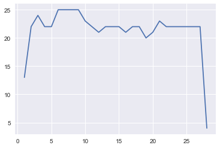

```python
plt.plot(episodes.season.value_counts(sort=False));
```

How does viewership change over time?

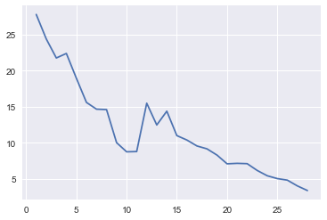

```python
plt.plot(episodes.groupby('season')['us_viewers_in_millions'].agg('mean'));
```

That's very interesting. Aside from a short-lived spike at season 12, viewership has been declining almost every year!

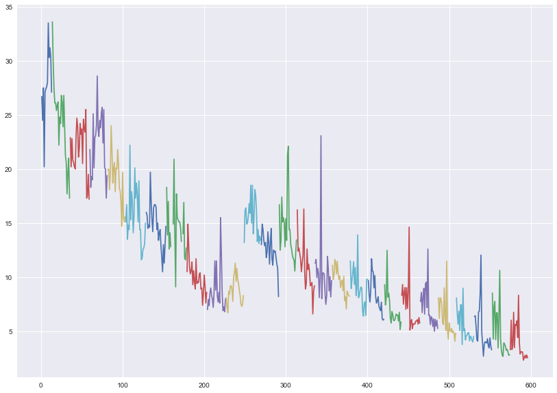

```python
fig, ax = plt.subplots(1, 1, figsize=(14,10))
for key, group in episodes.groupby('season'):
    ax.plot(group['us_viewers_in_millions']);
```

Plotting all episodes while coloring by season shows a drastic viewership difference depending on episode. Interestingly, most seasons show a spike where one episode has much greater viewership than the rest. I wonder if the famous Treehouse of Horror Halloween episodes are responsible for these spikes? The following table shows the most viewed episode for each season.

```python
episodes.loc[episodes.groupby('season')['us_viewers_in_millions'].idxmax(), ['title', 'original_air_date', 'us_viewers_in_millions']]
```

| id | title | original_air_date | us_viewers_in_millions |
| --- | --- | --- | --- |
| 9 | Life on the Fast Lane | 1990-03-18 | 33.50 |
| 14 | Bart Gets an "F" | 1990-10-11 | 33.60 |
| 55 | Colonel Homer | 1992-03-26 | 25.50 |
| 69 | Lisa's First Word | 1992-12-03 | 28.60 |
| 86 | Treehouse of Horror IV | 1993-10-28 | 24.00 |
| 109 | Treehouse of Horror V | 1994-10-30 | 22.20 |
| 134 | Treehouse of Horror VI | 1995-10-29 | 19.70 |
| 163 | The Springfield Files | 1997-01-12 | 20.90 |
| 180 | The Principal and the Pauper | 1997-09-28 | 14.90 |
| 220 | Maximum Homerdrive | 1999-03-28 | 15.50 |
| 238 | The Mansion Family | 2000-01-23 | 11.30 |
| 257 | HOMR | 2001-01-07 | 18.50 |
| 271 | The Parent Rap | 2001-11-11 | 14.90 |
| 303 | I'm Spelling As Fast As I Can | 2003-02-16 | 22.10 |
| 322 | I, (Annoyed Grunt)-bot | 2004-01-11 | 16.30 |
| 343 | Homer and Ned's Hail Mary Pass | 2005-02-06 | 23.07 |
| 360 | Treehouse of Horror XVI | 2005-11-06 | 11.63 |
| 388 | The Wife Aquatic | 2007-01-07 | 13.90 |
| 405 | Treehouse of Horror XVIII | 2007-11-04 | 11.70 |
| 424 | Treehouse of Horror XIX | 2008-11-02 | 12.48 |
| 451 | Once Upon a Time in Springfield | 2010-01-10 | 14.62 |
| 474 | Moms I'd Like to Forget | 2011-01-09 | 12.60 |
| 497 | The D'oh-cial Network | 2012-01-15 | 11.48 |
| 517 | Homer Goes to Prep School | 2013-01-06 | 8.97 |
| 539 | Steal This Episode | 2014-01-05 | 12.04 |
| 562 | The Man Who Came to Be Dinner | 2015-01-04 | 10.62 |
| 585 | Teenage Mutant Milk-Caused Hurdles | 2016-01-10 | 8.33 |
| 597 | Monty Burns' Fleeing Circus | 2016-09-25 | 3.36 |

Nope. The Treehouse of Horrow episodes only win in six seasons.

How does IMDB rating vary?

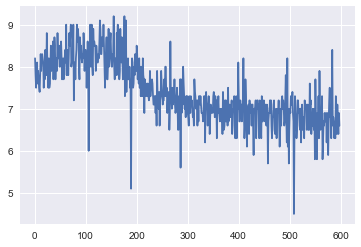

```python
plt.plot(episodes.imdb_rating);
```

It is interesting that although viewership rapidly declined in the early years, it appears that viewers liked episodes more up to about episode 175, where IMDB rating started to rapidly decrease as well. Here's another way of looking at the viewership and rating declines using a heatmap of the correlation table.

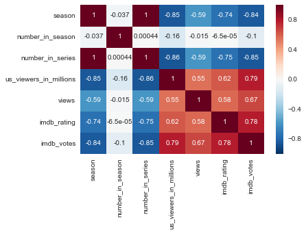

```python
sns.heatmap(episodes.corr(), annot=True);
```

Season and episode (number_in_series) are highly negatively correlated to viewership and rating.

# Dialog

I find the lines file, which contains all spoken lines and scenes from every episode, to be the most interesting.

```python
lines.drop(['number', 'raw_text', 'normalized_text'], axis=1).head()
```

| id | episode_id | timestamp_in_ms | speaking_line | character_id | location_id | raw_character_text | raw_location_text | spoken_words | word_count |
| --- | --- | --- | --- | --- | --- | --- | --- | --- | --- |
| 1 | 1 | 8000 | False | NaN | 1.0 | NaN | Street | NaN | NaN |
| 2 | 1 | 8000 | False | NaN | 2.0 | NaN | Car | NaN | NaN |
| 3 | 1 | 8000 | True | 1.0 | 2.0 | Marge Simpson | Car | Ooo, careful, Homer. | 3.0 |
| 4 | 1 | 10000 | True | 2.0 | 2.0 | Homer Simpson | Car | There's no time to be careful. | 6.0 |
| 5 | 1 | 10000 | True | 2.0 | 2.0 | Homer Simpson | Car | We're late. | 2.0 |

In this file, we get non-speaking lines, which establish scene locations, each followed by spoken lines of the characters in the scene. Timestamps are provided, along with character name, all spoken words, and word count. There is a lot we can do with this data.

## Who has the most lines?

```python
lines.groupby('raw_character_text').count().sort_values(by='normalized_text', ascending=False)
```

| raw_character_text | episode_id | number | raw_text | timestamp_in_ms | speaking_line | character_id | location_id | raw_location_text | spoken_words | normalized_text | word_count |
| --- | --- | --- | --- | --- | --- | --- | --- | --- | --- | --- | --- |
| Homer Simpson | 29850 | 29850 | 29850 | 29850 | 29850 | 29850 | 29780 | 29780 | 27920 | 27917 | 27920 |
| Marge Simpson | 14165 | 14165 | 14165 | 14165 | 14165 | 14165 | 14141 | 14141 | 13199 | 13197 | 13199 |
| Bart Simpson | 13780 | 13780 | 13780 | 13780 | 13780 | 13780 | 13766 | 13766 | 13016 | 13014 | 13016 |
| Lisa Simpson | 11505 | 11505 | 11505 | 11505 | 11505 | 11505 | 11488 | 11488 | 10772 | 10770 | 10772 |
| C. Montgomery Burns | 3172 | 3172 | 3172 | 3172 | 3172 | 3172 | 3172 | 3172 | 3087 | 3086 | 3087 |
| Moe Szyslak | 2864 | 2864 | 2864 | 2864 | 2864 | 2864 | 2862 | 2862 | 2810 | 2810 | 2810 |
| Seymour Skinner | 2443 | 2443 | 2443 | 2443 | 2443 | 2443 | 2438 | 2438 | 2390 | 2390 | 2390 |
| Ned Flanders | 2146 | 2146 | 2146 | 2146 | 2146 | 2146 | 2142 | 2142 | 2058 | 2057 | 2058 |
| Grampa Simpson | 1886 | 1886 | 1886 | 1886 | 1886 | 1886 | 1881 | 1881 | 1807 | 1807 | 1807 |
| Chief Wiggum | 1836 | 1836 | 1836 | 1836 | 1836 | 1836 | 1836 | 1836 | 1796 | 1796 | 1796 |
| Milhouse Van Houten | 1862 | 1862 | 1862 | 1862 | 1862 | 1862 | 1859 | 1859 | 1750 | 1750 | 1750 |
| Krusty the Clown | 1772 | 1772 | 1772 | 1772 | 1772 | 1772 | 1752 | 1752 | 1704 | 1704 | 1704 |
| Nelson Muntz | 1174 | 1174 | 1174 | 1174 | 1174 | 1174 | 1174 | 1174 | 1145 | 1145 | 1145 |
| Lenny Leonard | 1166 | 1166 | 1166 | 1166 | 1166 | 1166 | 1165 | 1165 | 1144 | 1144 | 1144 |
| Apu Nahasapeemapetilon | 1006 | 1006 | 1006 | 1006 | 1006 | 1006 | 1006 | 1006 | 988 | 988 | 988 |
| Waylon Smithers | 1001 | 1001 | 1001 | 1001 | 1001 | 1001 | 1001 | 1001 | 965 | 965 | 965 |
| Kent Brockman | 894 | 894 | 894 | 894 | 894 | 894 | 848 | 848 | 884 | 884 | 884 |
| Carl Carlson | 883 | 883 | 883 | 883 | 883 | 883 | 882 | 882 | 852 | 852 | 852 |
| Edna Krabappel-Flanders | 745 | 745 | 745 | 745 | 745 | 745 | 744 | 744 | 725 | 725 | 725 |
| Dr. Julius Hibbert | 693 | 693 | 693 | 693 | 693 | 693 | 693 | 693 | 673 | 673 | 673 |
| Selma Bouvier | 612 | 612 | 612 | 612 | 612 | 612 | 611 | 611 | 566 | 566 | 566 |
| Barney Gumble | 612 | 612 | 612 | 612 | 612 | 612 | 609 | 609 | 559 | 559 | 559 |
| Rev. Timothy Lovejoy | 562 | 562 | 562 | 562 | 562 | 562 | 562 | 562 | 554 | 554 | 554 |
| Sideshow Bob | 576 | 576 | 576 | 576 | 576 | 576 | 576 | 576 | 527 | 527 | 527 |
| Gary Chalmers | 526 | 526 | 526 | 526 | 526 | 526 | 526 | 526 | 519 | 519 | 519 |
| Groundskeeper Willie | 534 | 534 | 534 | 534 | 534 | 534 | 533 | 533 | 496 | 496 | 496 |
| Mayor Joe Quimby | 503 | 503 | 503 | 503 | 503 | 503 | 499 | 499 | 495 | 495 | 495 |
| Ralph Wiggum | 508 | 508 | 508 | 508 | 508 | 508 | 508 | 508 | 469 | 469 | 469 |
| Patty Bouvier | 479 | 479 | 479 | 479 | 479 | 479 | 479 | 479 | 463 | 463 | 463 |
| Comic Book Guy | 479 | 479 | 479 | 479 | 479 | 479 | 479 | 479 | 463 | 463 | 463 |
| ... | ... | ... | ... | ... | ... | ... | ... | ... | ... | ... | ... |
| Concert Crowd | 1 | 1 | 1 | 1 | 1 | 1 | 1 | 1 | 0 | 0 | 0 |
| Homer's Friends | 1 | 1 | 1 | 1 | 1 | 1 | 1 | 1 | 0 | 0 | 0 |
| Toy | 1 | 1 | 1 | 1 | 1 | 1 | 1 | 1 | 0 | 0 | 0 |
| 4-Year-Old Lisa | 2 | 2 | 2 | 2 | 2 | 2 | 2 | 2 | 0 | 0 | 0 |
| Ostrich | 5 | 5 | 5 | 5 | 5 | 5 | 5 | 5 | 1 | 0 | 1 |
| Other Board Members | 7 | 7 | 7 | 7 | 7 | 7 | 7 | 7 | 0 | 0 | 0 |
| Loch Ness Monster | 5 | 5 | 5 | 5 | 5 | 5 | 5 | 5 | 0 | 0 | 0 |
| Locals | 2 | 2 | 2 | 2 | 2 | 2 | 2 | 2 | 0 | 0 | 0 |
| SECOND ZOMBIE | 1 | 1 | 1 | 1 | 1 | 1 | 1 | 1 | 0 | 0 | 0 |
| Opal's Audience | 2 | 2 | 2 | 2 | 2 | 2 | 2 | 2 | 0 | 0 | 0 |
| Homer Drums | 1 | 1 | 1 | 1 | 1 | 1 | 1 | 1 | 0 | 0 | 0 |
| Toot-Toot | 4 | 4 | 4 | 4 | 4 | 4 | 4 | 4 | 0 | 0 | 0 |
| Committee Members | 2 | 2 | 2 | 2 | 2 | 2 | 2 | 2 | 0 | 0 | 0 |
| MINION MARGE SIMPSON | 1 | 1 | 1 | 1 | 1 | 1 | 1 | 1 | 0 | 0 | 0 |
| Threecan Sam | 1 | 1 | 1 | 1 | 1 | 1 | 1 | 1 | 0 | 0 | 0 |
| MINION HOMER SIMPSON | 1 | 1 | 1 | 1 | 1 | 1 | 1 | 1 | 0 | 0 | 0 |
| Fat Kids | 1 | 1 | 1 | 1 | 1 | 1 | 1 | 1 | 0 | 0 | 0 |
| MENSANS | 1 | 1 | 1 | 1 | 1 | 1 | 1 | 1 | 0 | 0 | 0 |
| Tiger | 1 | 1 | 1 | 1 | 1 | 1 | 1 | 1 | 0 | 0 | 0 |
| Bongo | 1 | 1 | 1 | 1 | 1 | 1 | 1 | 1 | 0 | 0 | 0 |
| SUDS MCDUFF | 1 | 1 | 1 | 1 | 1 | 1 | 1 | 1 | 0 | 0 | 0 |
| Homer Devils | 1 | 1 | 1 | 1 | 1 | 1 | 1 | 1 | 0 | 0 | 0 |
| Baboon | 2 | 2 | 2 | 2 | 2 | 2 | 2 | 2 | 0 | 0 | 0 |
| Babies | 5 | 5 | 5 | 5 | 5 | 5 | 5 | 5 | 0 | 0 | 0 |
| MANATEE | 5 | 5 | 5 | 5 | 5 | 5 | 5 | 5 | 0 | 0 | 0 |
| SPERM #3, #4, & #5 | 1 | 1 | 1 | 1 | 1 | 1 | 1 | 1 | 0 | 0 | 0 |
| German | 1 | 1 | 1 | 1 | 1 | 1 | 1 | 1 | 0 | 0 | 0 |
| SMITTEN GIRL WHO FAINTS | 1 | 1 | 1 | 1 | 1 | 1 | 1 | 1 | 0 | 0 | 0 |
| Gerbil | 1 | 1 | 1 | 1 | 1 | 1 | 1 | 1 | 0 | 0 | 0 |
| HUGE BLUE WHALE | 1 | 1 | 1 | 1 | 1 | 1 | 1 | 1 | 0 | 0 | 0 |

6767 rows × 11 columns

There is an interesting discrepancy depending on which column we use for counting. For Homer, for example, you get anywhere from 27917 up to 29850. The discrepancy must result from some NA values in certain columns.

```python
lines.loc[(lines.raw_character_text == 'Homer Simpson') & (lines.word_count.isnull())][:5]
```

| id | episode_id | number | raw_text | timestamp_in_ms | speaking_line | character_id | location_id | raw_character_text | raw_location_text | spoken_words | normalized_text | word_count |
| --- | --- | --- | --- | --- | --- | --- | --- | --- | --- | --- | --- | --- |
| 123 | 1 | 122 | Homer Simpson: (SHRIEKS) | 513000 | False | 2.0 | 5.0 | Homer Simpson | Simpson Home | NaN | NaN | NaN |
| 187 | 1 | 186 | Homer Simpson: (SHUDDERS) | 754000 | False | 2.0 | 5.0 | Homer Simpson | Simpson Home | NaN | NaN | NaN |
| 324 | 1 | 323 | Homer Simpson: (GROANS LIKE HE'S HAVING A HEAR... | 1171000 | False | 2.0 | 21.0 | Homer Simpson | SPRINGFIELD DOWNS | NaN | NaN | NaN |
| 328 | 1 | 327 | Homer Simpson: (GROAN) | 1194000 | False | 2.0 | 21.0 | Homer Simpson | SPRINGFIELD DOWNS | NaN | NaN | NaN |
| 612 | 2 | 234 | Homer Simpson: (GRUNTS) | 1078000 | False | 2.0 | 5.0 | Homer Simpson | Simpson Home | NaN | NaN | NaN |

Now we see where the difference come from. Homer has a lot of lines that are just grunts and groans with no spoken words! Let's go ahead and count those anyway.

```python
lines.groupby('raw_character_text')['raw_text'].count().sort_values(ascending=False)[:40]
```

```
raw_character_text
Homer Simpson               29850
Marge Simpson               14165
Bart Simpson                13780
Lisa Simpson                11505
C. Montgomery Burns          3172
Moe Szyslak                  2864
Seymour Skinner              2443
Ned Flanders                 2146
Grampa Simpson               1886
Milhouse Van Houten          1862
Chief Wiggum                 1836
Krusty the Clown             1772
Nelson Muntz                 1174
Lenny Leonard                1166
Apu Nahasapeemapetilon       1006
Waylon Smithers              1001
Kent Brockman                 894
Carl Carlson                  883
Edna Krabappel-Flanders       745
Dr. Julius Hibbert            693
Selma Bouvier                 612
Barney Gumble                 612
Sideshow Bob                  576
Rev. Timothy Lovejoy          562
Crowd                         540
Groundskeeper Willie          534
Gary Chalmers                 526
Ralph Wiggum                  508
Mayor Joe Quimby              503
Patty Bouvier                 479
Comic Book Guy                479
Otto Mann                     424
Martin Prince                 410
Announcer                     387
Kids                          366
Jimbo Jones                   357
Sideshow Mel                  352
Lou                           351
Professor Jonathan Frink      341
Kearney Zzyzwicz              280
Name: raw_text, dtype: int64
```

## How about the most number of words? No grunts allowed.

```python
lines.groupby('raw_character_text')['word_count'].sum().sort_values(ascending=False)[:40]
```

```
raw_character_text
Homer Simpson               271289.0
Marge Simpson               124767.0
Bart Simpson                109160.0
Lisa Simpson                 99251.0
C. Montgomery Burns          36212.0
Moe Szyslak                  32862.0
Seymour Skinner              28138.0
Ned Flanders                 22922.0
Krusty the Clown             20701.0
Chief Wiggum                 19992.0
Grampa Simpson               19510.0
Kent Brockman                15998.0
Milhouse Van Houten          14543.0
Apu Nahasapeemapetilon       11483.0
Lenny Leonard                 9852.0
Waylon Smithers               9533.0
Nelson Muntz                  8475.0
Dr. Julius Hibbert            7779.0
Edna Krabappel-Flanders       7300.0
Carl Carlson                  7150.0
Rev. Timothy Lovejoy          6864.0
Sideshow Bob                  6402.0
Mayor Joe Quimby              6135.0
Comic Book Guy                5719.0
Gary Chalmers                 5668.0
Selma Bouvier                 4928.0
Announcer                     4926.0
Professor Jonathan Frink      4817.0
Groundskeeper Willie          4804.0
Barney Gumble                 4458.0
Patty Bouvier                 3803.0
Martin Prince                 3748.0
Otto Mann                     3579.0
Sideshow Mel                  3359.0
Ralph Wiggum                  3022.0
Fat Tony                      2973.0
Lou                           2702.0
Jimbo Jones                   2657.0
Troy McClure                  2601.0
Kirk Van Houten               2507.0
Name: word_count, dtype: float64
```

```python
print('Total word count:', lines.word_count.sum())
```

```
Total word count: 1306503.0
```

Either way you look at it, Homer absolutely dominates the dialog in The Simpsons. All four of the main family characters are well above Mr. Burns, who comes in at fifth place. In fact, the main family speaks 604,467 words, which accounts for more than 46% of the total!

How consistent is the number of lines for Homer?

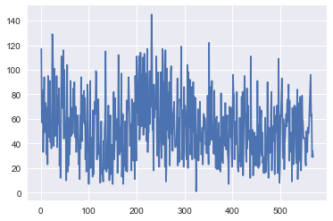

```python
plt.plot(lines.loc[lines.raw_character_text == 'Homer Simpson'].groupby('episode_id')['raw_text'].count());
```

Interestingly, there are many episodes where Homer has fewer than 20 lines, and many others where he exceeds 100.

### Does the relative importance of characters change over time?

We'll merge in season from the episodes file, then group by season and character to count the number of lines per character per season. To simplify things, we'll regroup just on season so that we can sort by character and take only the top 10 characters each season.

```python
lines = lines.merge(episodes[['season']], how='left', left_on='episode_id', right_index=True)
character_season_lines = lines.groupby(['season', 'raw_character_text'])['raw_text'].count()

top_10_by_season = character_season_lines.groupby(level=0, group_keys=False).apply(lambda x: x.sort_values(ascending=False).nlargest(10))

top_10_by_season.reset_index()[:20]
```

|  | season | raw_character_text | raw_text |
| --- | --- | --- | --- |
| 0 | 1 | Homer Simpson | 848 |
| 1 | 1 | Bart Simpson | 671 |
| 2 | 1 | Marge Simpson | 453 |
| 3 | 1 | Lisa Simpson | 277 |
| 4 | 1 | Jacques | 59 |
| 5 | 1 | C. Montgomery Burns | 52 |
| 6 | 1 | Seymour Skinner | 51 |
| 7 | 1 | Krusty the Clown | 43 |
| 8 | 1 | Dr. Marvin Monroe | 41 |
| 9 | 1 | Moe Szyslak | 39 |
| 10 | 2 | Homer Simpson | 1467 |
| 11 | 2 | Bart Simpson | 773 |
| 12 | 2 | Marge Simpson | 708 |
| 13 | 2 | Lisa Simpson | 432 |
| 14 | 2 | C. Montgomery Burns | 266 |
| 15 | 2 | Grampa Simpson | 190 |
| 16 | 2 | Waylon Smithers | 105 |
| 17 | 2 | Ned Flanders | 82 |
| 18 | 2 | Seymour Skinner | 76 |
| 19 | 2 | HERB | 74 |

A pivot table will allow us to put seasons in the rows and characters in the columns so that we can see how the number of lines varies for each character as the seasons go by.

```python
top_10_by_season = pd.pivot_table(top_10_by_season.reset_index(), index='season', columns='raw_character_text')
top_10_by_season
```

| raw_character_text season | raw_text Adult Bart | raw_text Apu Nahasapeemapetilon | raw_text Barney Gumble | raw_text Bart Simpson | raw_text C. Montgomery Burns | raw_text Carl Carlson | raw_text Chief Wiggum | raw_text Comic Book Guy | raw_text Dr. Marvin Monroe | raw_text ELON MUSK | raw_text ... | raw_text Lisa Simpson | raw_text Marge Simpson | raw_text Milhouse Van Houten | raw_text Moe Szyslak | raw_text Narrator | raw_text Ned Flanders | raw_text Nelson Muntz | raw_text Seymour Skinner | raw_text Waylon Smithers | raw_text Young Marge |
| --- | --- | --- | --- | --- | --- | --- | --- | --- | --- | --- | --- | --- | --- | --- | --- | --- | --- | --- | --- | --- | --- |
| 1 | NaN | NaN | NaN | 671.0 | 52.0 | NaN | NaN | NaN | 41.0 | NaN | ... | 277.0 | 453.0 | NaN | 39.0 | NaN | NaN | NaN | 51.0 | NaN | NaN |
| 2 | NaN | NaN | NaN | 773.0 | 266.0 | NaN | NaN | NaN | NaN | NaN | ... | 432.0 | 708.0 | NaN | NaN | NaN | 82.0 | NaN | 76.0 | 105.0 | NaN |
| 3 | NaN | NaN | NaN | 771.0 | 245.0 | NaN | NaN | NaN | NaN | NaN | ... | 410.0 | 576.0 | NaN | 132.0 | NaN | 81.0 | NaN | 95.0 | 108.0 | NaN |
| 4 | NaN | NaN | 73.0 | 577.0 | 117.0 | NaN | 75.0 | NaN | NaN | NaN | ... | 396.0 | 536.0 | NaN | NaN | NaN | NaN | NaN | 88.0 | NaN | NaN |
| 5 | NaN | 112.0 | NaN | 547.0 | 221.0 | NaN | 86.0 | NaN | NaN | NaN | ... | 318.0 | 416.0 | NaN | NaN | NaN | 123.0 | NaN | 147.0 | NaN | NaN |
| 6 | NaN | NaN | NaN | 716.0 | 123.0 | NaN | NaN | NaN | NaN | NaN | ... | 585.0 | 663.0 | 85.0 | 87.0 | NaN | NaN | NaN | 165.0 | NaN | NaN |
| 7 | NaN | 97.0 | NaN | 638.0 | 253.0 | NaN | 99.0 | NaN | NaN | NaN | ... | 557.0 | 447.0 | 141.0 | NaN | NaN | NaN | NaN | NaN | 130.0 | NaN |
| 8 | NaN | NaN | NaN | 588.0 | 231.0 | NaN | 129.0 | NaN | NaN | NaN | ... | 515.0 | 558.0 | NaN | 151.0 | NaN | 118.0 | 79.0 | 146.0 | NaN | NaN |
| 9 | NaN | 109.0 | NaN | 670.0 | NaN | NaN | 83.0 | NaN | NaN | NaN | ... | 567.0 | 671.0 | NaN | 192.0 | NaN | 89.0 | NaN | 81.0 | NaN | NaN |
| 10 | NaN | NaN | NaN | 500.0 | 107.0 | NaN | 140.0 | NaN | NaN | NaN | ... | 562.0 | 648.0 | NaN | 79.0 | NaN | 117.0 | NaN | 136.0 | NaN | NaN |
| 11 | NaN | 95.0 | NaN | 602.0 | NaN | NaN | NaN | NaN | NaN | NaN | ... | 488.0 | 593.0 | 71.0 | 145.0 | 67.0 | 124.0 | NaN | 80.0 | NaN | NaN |
| 12 | NaN | NaN | NaN | 451.0 | NaN | NaN | 104.0 | NaN | NaN | NaN | ... | 464.0 | 453.0 | 104.0 | 82.0 | NaN | 130.0 | NaN | 128.0 | NaN | NaN |
| 13 | NaN | 75.0 | NaN | 440.0 | 153.0 | NaN | 108.0 | NaN | NaN | NaN | ... | 443.0 | 633.0 | NaN | 181.0 | NaN | NaN | NaN | NaN | NaN | NaN |
| 14 | NaN | NaN | NaN | 433.0 | NaN | NaN | 78.0 | NaN | NaN | NaN | ... | 448.0 | 588.0 | 90.0 | 183.0 | NaN | 126.0 | NaN | 108.0 | NaN | NaN |
| 15 | NaN | NaN | NaN | 496.0 | 120.0 | NaN | 83.0 | NaN | NaN | NaN | ... | 521.0 | 578.0 | 86.0 | 60.0 | NaN | NaN | NaN | 108.0 | NaN | NaN |
| 16 | NaN | NaN | NaN | 421.0 | 79.0 | NaN | 94.0 | NaN | NaN | NaN | ... | 395.0 | 608.0 | NaN | 94.0 | NaN | 136.0 | 63.0 | 63.0 | NaN | NaN |
| 17 | NaN | NaN | NaN | 372.0 | 109.0 | NaN | NaN | NaN | NaN | NaN | ... | 425.0 | 666.0 | 90.0 | 114.0 | NaN | 82.0 | NaN | 83.0 | NaN | NaN |
| 18 | NaN | NaN | NaN | 478.0 | NaN | NaN | NaN | NaN | NaN | NaN | ... | 407.0 | 519.0 | 69.0 | 142.0 | NaN | NaN | 84.0 | 103.0 | NaN | NaN |
| 19 | NaN | NaN | NaN | 443.0 | 59.0 | NaN | NaN | NaN | NaN | NaN | ... | 397.0 | 442.0 | 75.0 | NaN | NaN | NaN | 67.0 | 82.0 | NaN | 58.0 |
| 20 | NaN | NaN | NaN | 397.0 | 94.0 | NaN | NaN | NaN | NaN | NaN | ... | 475.0 | 476.0 | 54.0 | 137.0 | NaN | 113.0 | NaN | 98.0 | NaN | NaN |
| 21 | NaN | NaN | NaN | 606.0 | 106.0 | 80.0 | 117.0 | NaN | NaN | NaN | ... | 420.0 | 466.0 | NaN | 173.0 | NaN | 119.0 | NaN | NaN | NaN | NaN |
| 22 | NaN | NaN | NaN | 523.0 | 105.0 | NaN | NaN | NaN | NaN | NaN | ... | 536.0 | 463.0 | 91.0 | 122.0 | NaN | NaN | 103.0 | 123.0 | NaN | NaN |
| 23 | NaN | NaN | NaN | 473.0 | 91.0 | NaN | NaN | NaN | NaN | NaN | ... | 385.0 | 455.0 | NaN | 79.0 | NaN | 98.0 | NaN | 77.0 | NaN | NaN |
| 24 | NaN | NaN | NaN | 455.0 | 106.0 | NaN | NaN | NaN | NaN | NaN | ... | 394.0 | 649.0 | 90.0 | 186.0 | NaN | 94.0 | NaN | NaN | NaN | NaN |
| 25 | 62.0 | NaN | NaN | 465.0 | 76.0 | NaN | NaN | 58.0 | NaN | NaN | ... | 464.0 | 512.0 | 108.0 | 55.0 | NaN | NaN | NaN | 104.0 | NaN | NaN |
| 26 | NaN | 64.0 | NaN | 274.0 | 147.0 | NaN | 51.0 | NaN | NaN | 51.0 | ... | 224.0 | 388.0 | NaN | 157.0 | NaN | NaN | NaN | NaN | NaN | NaN |

26 rows × 28 columns

Over the 26 seasons of data we have, there are 28 different characters that have appeared in the top 10 for a season.

[figure not shown]

```python
fig, ax = plt.subplots(figsize=(12, 12))
top_10_by_season.apply(lambda x: ax.plot(x, label=x.name[1]))
legend = ax.legend(fontsize='x-large', frameon=True, bbox_to_anchor=(1, 1));
legend.get_frame().set_facecolor('lightgrey')
```

Homer has always been #1 but saw a great spike in number of lines in seasons 9-11. Bart had the second most number of lines in the early seasons, while Lisa had considerably fewer lines. In later seasons, Bart fell in importance to be almost matched with Lisa, while Marge took more prominence. Mr. Burns was perhaps the next most important character after the main Simpson family members in the earliest seasons. In some middle seasons, he dropped out of the top ten, but regained that status consistently in the latest seasons.

It is interesting that two guest stars show up in the top 10 most lines for the season, Elon Musk and Lady Gaga!

### How many episodes do the characters appear in?

```python
print('Total episodes:', lines.episode_id.nunique())
```

```
Total episodes: 564
```

```python
lines.groupby('raw_character_text')['episode_id'].nunique().sort_values(ascending=False)[:40]
```

```
raw_character_text
Homer Simpson               564
Marge Simpson               563
Bart Simpson                562
Lisa Simpson                562
Moe Szyslak                 376
Milhouse Van Houten         325
Lenny Leonard               319
Chief Wiggum                318
Seymour Skinner             297
Carl Carlson                282
Ned Flanders                281
Nelson Muntz                277
Grampa Simpson              265
C. Montgomery Burns         241
Krusty the Clown            238
Kent Brockman               233
Dr. Julius Hibbert          207
Crowd                       204
Apu Nahasapeemapetilon      197
Ralph Wiggum                188
Announcer                   185
Barney Gumble               181
Waylon Smithers             179
Groundskeeper Willie        167
Lou                         150
Sideshow Mel                149
Kids                        147
Otto Mann                   137
Mayor Joe Quimby            137
Jimbo Jones                 133
Rev. Timothy Lovejoy        132
Martin Prince               131
Edna Krabappel-Flanders     130
Kearney Zzyzwicz            125
Comic Book Guy              123
Patty Bouvier               107
Selma Bouvier               104
Cletus Spuckler             101
Professor Jonathan Frink    100
Gary Chalmers                98
Name: episode_id, dtype: int64
```

Homer has appeard in all 564 episodes for which we have data. Marge has only missed one, while Bart and Lisa have each missed just two. There are a couple of surprises. Mr. Burns, who is fifth in overall lines spoken, is only 14th in number of episodes. Also, I would not have guessed that Prof. Frink and Cletus appear in 100 episodes each.

## Most popular locations

```python
lines.groupby('raw_location_text')['episode_id'].count().sort_values(ascending=False)[:40]
```

```
raw_location_text
Simpson Home                                  35066
Springfield Elementary School                  7094
Moe's Tavern                                   4633
Springfield Nuclear Power Plant                3598
Kwik-E-Mart                                    1476
First Church of Springfield                    1416
Simpson Living Room                            1378
Springfield Street                             1334
Springfield                                    1314
Simpson Car                                    1239
Flanders Home                                  1166
Street                                         1124
Springfield Town Hall                          1103
Springfield Retirement Castle                  1049
Burns Manor                                     999
Springfield Mall                                833
Simpson Kitchen                                 816
Courtroom                                       813
Bart's Treehouse                                767
Bart's Bedroom                                  766
Springfield Town Square                         710
Lisa's Bedroom                                  644
Springfield Police Station                      631
Skinner's Office                                628
Burns's Office                                  627
Park                                            617
The Android's Dungeon & Baseball Card Shop      610
Evergreen Terrace                               603
Homer's Car                                     574
Car                                             564
Springfield Convention Center                   545
STADIUM                                         525
Hospital                                        507
Theater                                         499
Simpson Backyard                                493
Bus                                             478
Krustylu Studios                                473
TV Studio                                       464
LIVING ROOM                                     453
KITCHEN                                         443
Name: episode_id, dtype: int64
```

The Simpson home, is of course, the most popular location. Many other locations in the list are just more specific locations within their home, such as Bart's Treehouse and Lisa's Bedroom. Outside of their home, the most popular locations are Springfield Elementary, Moe's Tavern, and the Nuclear Power Plant. No surprises there.

# Create graph data linking characters

## I defined groups consisting of the Simpsons family, people from Springfield Elementary, people from the power plant, and everyone else. We will see if those groups tend to congregate in the graph.

```python
import math
import itertools
from collections import defaultdict

#use only 50 characters to prevent overly complicated graph
short_list = list(lines.groupby('character_id').count().sort_values(by='normalized_text', ascending=False).index)
short_list = [int(i) for i in short_list][:50]

graph_data = defaultdict(lambda: 0)
characters = []

def process_line(x=None):
    global characters
    if x is None:
        characters = set(characters)
        for i, j in itertools.combinations(characters, 2):
            if i < j:
                graph_data[(i, j)] += 1
            else:
                graph_data[(j, i)] += 1
        return
    else:
        if x['speaking_line'] == False:
            characters = set(sorted(characters))
            for i, j in itertools.combinations(characters, 2):
                if i < j:
                    graph_data[(i, j)] += 1
                else:
                    graph_data[(j, i)] += 1
            characters = []
            return
        else:
            if not math.isnan(x.character_id) and int(x.character_id) in short_list:
                characters.append(int(x.character_id))

lines.apply(lambda x: process_line(x), axis=1)
process_line()
```

```python
plt.hist(list(graph_data.values()), bins=50, range=(0, 500));
```

[output not shown]

```python
#remove keys with value 1 to lower complexity of graph
graph_data = {k:v for k, v in graph_data.items() if v > 1}

group_1 = ['Homer Simpson', 'Marge Simpson', 'Bart Simpson', 'Lisa Simpson', 'Grampa Simpson']
group_2 = ['Seymour Skinner', 'Milhouse Van Houten', 'Nelson Muntz', 'Edna Krabappel-Flanders', 'Martin Prince', 'Otto Mann',
          'Ralph Wiggum', 'Jimbo Jones', 'Kearney Zzyzwicz', 'DOLPH', 'Groundskeeper Willie', 'Gary Chalmers']
group_3 = ['Waylon Smithers', 'Lenny Leonard', 'Carl Carlson', 'C. Montgomery Burns']

# create nodes list
nodes = pd.read_csv('simpsons_characters.csv')
short_nodes = nodes[nodes.id.isin(short_list)].reset_index()
nodes_list = []

def add_node(x):
    global nodes_list
    if int(x['id']) in short_list:
        if x['name'] in group_1:
            group = 1
        elif x['name'] in group_2:
            group = 2
        elif x['name'] in group_3:
            group = 3
        else:
            group = 4
        nodes_list.append({'group':group, 'name':x['name']})

short_nodes.apply(lambda x: add_node(x), axis=1);

links_list = []
for (i, j), strength in graph_data.items():
    links_list.append({'source':int(short_nodes.loc[short_nodes.id==i].index[0]),
                       'target':int(short_nodes.loc[short_nodes.id==j].index[0]),
                       'value':strength})

import json

json_prep = {"nodes":nodes_list, "links":links_list}
json_dump = json.dumps(json_prep, indent=1, sort_keys=True)

filename_out = 'simpsons_graph.json'
json_out = open(filename_out,'w')
json_out.write(json_dump)
json_out.close()
```

# Vocabulary of characters

```python
from nltk.corpus import stopwords
from nltk.tokenize import RegexpTokenizer

all_speech = lines.dropna(subset=['normalized_text']).groupby('raw_character_text')['spoken_words'].agg(' '.join)

stop_words = set(stopwords.words('english'))

def proc(x):
    tokenizer = RegexpTokenizer(r'\w+')
    #print(x)
    #print(sent_tokenize(x))
    #tokens = word_tokenize(sent_tokenize(x))
    return [word.lower() for word in tokenizer.tokenize(x) if word not in stop_words]

all_speech_nostop = pd.DataFrame(all_speech.apply(lambda x: proc(x)))

all_speech_nostop['total words'] = all_speech_nostop['spoken_words'].transform(len)
all_speech_nostop['vocab size'] = all_speech_nostop['spoken_words'].transform(lambda x: len(set(x)))
all_speech_nostop['vocab:total ratio'] = all_speech_nostop['vocab size'] / all_speech_nostop['total words']

all_speech_nostop.sort_values(by='total words', ascending=False, inplace=True)

all_speech_nostop.head(10)
```

| raw_character_text | spoken_words | total words | vocab size | vocab:total ratio |
| --- | --- | --- | --- | --- |
| Homer Simpson | [there, time, careful, we, late, hey, norman, ... | 175490 | 15435 | 0.087954 |
| Marge Simpson | [ooo, careful, homer, sorry, excuse, us, pardo... | 76699 | 9602 | 0.125191 |
| Bart Simpson | [jingle, bells, batman, smells, robin, laid, a... | 71209 | 9515 | 0.133621 |
| Lisa Simpson | [but, i, really, want, pony, i, really, really... | 63080 | 10165 | 0.161145 |
| C. Montgomery Burns | [hello, i, proud, announce, able, increase, sa... | 23117 | 6155 | 0.266254 |
| Moe Szyslak | [what, matter, homer, somebody, leave, lumpa, ... | 21254 | 4716 | 0.221888 |
| Seymour Skinner | [wasn, wonderful, and, santas, many, lands, pr... | 17804 | 4932 | 0.277016 |
| Ned Flanders | [just, hold, horses, son, hey, hey, simpson, d... | 14964 | 4062 | 0.271451 |
| Krusty the Clown | [kill, well, right, go, ahead, there, someone,... | 13588 | 3899 | 0.286944 |
| Chief Wiggum | [well, secret, city, siege, graffiti, vandal, ... | 12693 | 3483 | 0.274403 |

```python
all_speech_nostop.sort_values(by='vocab size', ascending=False).head(10)
```

| raw_character_text | spoken_words | total words | vocab size | vocab:total ratio |
| --- | --- | --- | --- | --- |
| Homer Simpson | [there, time, careful, we, late, hey, norman, ... | 175490 | 15435 | 0.087954 |
| Lisa Simpson | [but, i, really, want, pony, i, really, really... | 63080 | 10165 | 0.161145 |
| Marge Simpson | [ooo, careful, homer, sorry, excuse, us, pardo... | 76699 | 9602 | 0.125191 |
| Bart Simpson | [jingle, bells, batman, smells, robin, laid, a... | 71209 | 9515 | 0.133621 |
| C. Montgomery Burns | [hello, i, proud, announce, able, increase, sa... | 23117 | 6155 | 0.266254 |
| Seymour Skinner | [wasn, wonderful, and, santas, many, lands, pr... | 17804 | 4932 | 0.277016 |
| Moe Szyslak | [what, matter, homer, somebody, leave, lumpa, ... | 21254 | 4716 | 0.221888 |
| Kent Brockman | [good, evening, springfield, krusty, clown, be... | 10232 | 4117 | 0.402365 |
| Ned Flanders | [just, hold, horses, son, hey, hey, simpson, d... | 14964 | 4062 | 0.271451 |
| Krusty the Clown | [kill, well, right, go, ahead, there, someone,... | 13588 | 3899 | 0.286944 |

## Homer has, by far, the greatest number of unique words, but mostly because he dominates the dialog of The Simpsons.

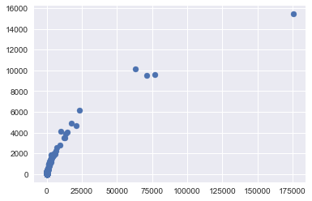

```python
plt.scatter(all_speech_nostop['total words'], all_speech_nostop['vocab size']);
```

## There is a definite correlation between total words spoken and unique vocabulary. Homer dominates both, but I don't believe unique vocab words itself is a good measure of sophistication of speech.

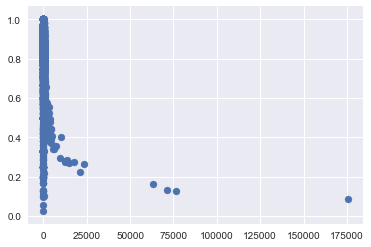

```python
plt.scatter(all_speech_nostop['total words'], all_speech_nostop['vocab:total ratio']);
```

## The unique vocab to total words ratio would be expected to decline with more words because additional words are more likely to have been used before.

## Instead, for each character, let's plot a curve showing how many unique words have been used vs. the total number of words spoken. I am limiting the calculation at 20,000 total words because most characters don't surpass that number and because the set calculations for much larger lists were taking a long time.

```python
all_speech_nostop['new vocab curve'] = all_speech_nostop.ix[:30, 'spoken_words'].apply(lambda x: [len(set(x[:i])) for i in range(min(len(x), 20000))])
```

[figure not shown]

```python
fig, ax = plt.subplots(figsize=(12, 12))
for i in range(30):
    plt.plot(all_speech_nostop.ix[i, 'new vocab curve'],  label=str(all_speech_nostop.index[i]));
legend = ax.legend(fontsize='x-large', frameon=True, bbox_to_anchor=(1, 1));
legend.get_frame().set_facecolor('lightgrey')
```

[figure not shown]

```python
fig, ax = plt.subplots(figsize=(12, 12))
#ax.set_xlim(-100, 100)
for i in [11, 22, 23, 25, 29]:#range(10,30):
    plt.plot(all_speech_nostop.ix[i, 'new vocab curve'],  label=str(all_speech_nostop.index[i]));
legend = ax.legend(fontsize='x-large', frameon=True, bbox_to_anchor=(1, 1));
legend.get_frame().set_facecolor('lightgrey')
```

In the early range up to ~5000 words, there appears to be 3 groups. In the lowest group, we find some of the most important characters, including Homer, Marge, Bart, and Moe. I am not surprised that Homer has the shallowest vocab curve, but I am a bit surprised that Marge runs neck-and-neck with Homer most of the way. I guess I expected her to be significantly ahead of him. Another surprise to me was that Moe begins to overtake all main Simpsons family members except Lisa. Bart is also well ahead of Homer and Marge, but not Lisa, of course. Lisa falls in the middle group early on, but ends with a respectable vocabulary. Within the middle group, Mr. Burns and Principal Skinner are at the top, and at the 17,500 word mark, they easily have the greatest vocabularies. The high fliers early on include the Announcer, Kent Brockman, Comic Book Guy, Prof. Frink, and Mayor Joe Quimby. All except Kent Brockman have far fewer total words than other characters, but add new words at the greatest pace. Kent Brockman really stands out, adding new words at a faster pace all the way up to the 10,000 word mark. Within this group, Comic Book Guy surprised me the most!

I think this curve is a better way of measuring sophistication of speech because it lets you compare characters on an equal-word basis.

# Sentiment Analysis

```python
from textblob import TextBlob
```

```python
character_sentiment = all_speech.apply(lambda x: TextBlob(x).sentiment)
```

```python
character_sentiment[all_speech_nostop.index]
```

```
raw_character_text
Homer Simpson               (0.13194846843483793, 0.5435141745609743)
Marge Simpson               (0.14635502685147264, 0.5425813391464799)
Bart Simpson                (0.11235737855279213, 0.5337834095543028)
Lisa Simpson                (0.12428649868802827, 0.5395144596314508)
C. Montgomery Burns          (0.14663707204277807, 0.533503759516419)
Moe Szyslak                 (0.13082862378394103, 0.5335130792034565)
Seymour Skinner             (0.13713046187497635, 0.5175495519456836)
Ned Flanders                (0.13734508842659923, 0.5137823052679973)
Krusty the Clown            (0.12633520665682446, 0.5189613890383132)
Chief Wiggum                 (0.12354568675427824, 0.519333291275739)
Grampa Simpson              (0.10613904471846182, 0.4955120454258391)
Kent Brockman               (0.09232381778607178, 0.4793536358689537)
Milhouse Van Houten         (0.15528102254234574, 0.5475663119900867)
Apu Nahasapeemapetilon      (0.12723245372792488, 0.5409085952575879)
Lenny Leonard                (0.13345606026086507, 0.540789376439887)
Waylon Smithers             (0.11194089598495131, 0.5124862699489564)
Nelson Muntz                 (0.1079807229850576, 0.5251337441740282)
Dr. Julius Hibbert          (0.05250630291368586, 0.5670075271321489)
Carl Carlson                 (0.1553291864240762, 0.5134829069919977)
Edna Krabappel-Flanders     (0.13269270477329703, 0.5175259229987842)
Rev. Timothy Lovejoy        (0.09668715668367157, 0.5074428968388079)
Sideshow Bob                (0.11567193712993144, 0.5249465868764115)
Mayor Joe Quimby            (0.12138279028607349, 0.5285116998566367)
Comic Book Guy               (0.1327553738246141, 0.5210251440643601)
Gary Chalmers                (0.1174275586883198, 0.5128302408217461)
Announcer                   (0.15614104780008148, 0.4983149303798661)
Groundskeeper Willie        (0.1338473413798788, 0.48852409282494036)
Selma Bouvier               (0.16751978872151632, 0.5176373009706339)
Barney Gumble                  (0.1413139354338695, 0.53469671994672)
Professor Jonathan Frink     (0.1158917648869495, 0.5365225270608905)
                                              ...
Uma                                                        (0.0, 0.0)
Gheet                                                      (0.0, 0.0)
Angry Sergeant                                             (0.0, 0.0)
Old Mrs. Glick                                             (0.0, 0.0)
VOICE OVER MEGAPHONE                                       (0.0, 0.0)
Octopus                                                    (0.0, 0.0)
Octoparrot                                                 (0.0, 0.0)
Nuts & Bolts                                              (-0.4, 0.4)
```

[output cut: 8 more lines]

```
Sushi Bar Chefs                                            (0.0, 0.0)
Nearby Patient                                             (0.0, 0.0)
Hairdresser                                                (0.0, 0.0)
Villageville Crowd                                         (0.0, 0.0)
Alf                                                        (0.0, 0.0)
Handsome Young Man                                         (0.0, 0.0)
Nabendu                                                    (0.0, 0.0)
Congress                                                   (0.0, 0.0)
Voice From The Back                                        (0.0, 0.0)
NICHOLSON                                                  (0.0, 0.0)
Super Bowl Crowd                                           (0.0, 0.0)
EURO-TRASH VOICE                                           (0.0, 0.0)
Pria                                                       (0.0, 0.0)
Sashi                                                      (0.0, 0.0)
Name: spoken_words, Length: 6280, dtype: object
```

### Sentiment by episode

```python
dialog_by_episode = lines.dropna(subset=['normalized_text']).groupby('episode_id')['spoken_words'].agg(' '.join)
```

```python
episode_sentiment = dialog_by_episode.apply(lambda x: TextBlob(x).sentiment)
```

```python
episode_sentiment.sort_values(ascending=False)
```

```
episode_id
9        (0.2684297461894743, 0.5361525707198783)
225      (0.2534824969590594, 0.5535940448440448)
286     (0.24963962688877236, 0.5725088183421518)
278     (0.23808631053715326, 0.5473445530748897)
425     (0.23722400903249674, 0.5341388454477457)
116     (0.23227319490194948, 0.5459318230313379)
406     (0.23125650550726165, 0.5243187403993856)
31      (0.22873758229006916, 0.5380214920707883)
82      (0.22792797968449882, 0.5417937654692618)
446    (0.22663412629197047, 0.46243249193616864)
177     (0.22532870978543273, 0.5003923647015754)
385     (0.22100062786846636, 0.5303283830367165)
303      (0.2162033796879142, 0.5469435609741732)
407     (0.21041496873155252, 0.5489295086226903)
```

[output cut: 48 more lines]

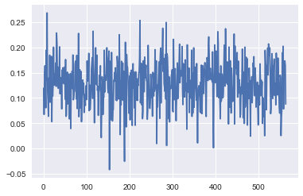

```python
plt.plot([x[0] for x in episode_sentiment]);
```